# ++MT_ReneWindProject_LearnerNotebook_FullCode++ipynb

##### xgb oversampled tuned

```
Fitting 3 folds for each of 30 candidates, totalling 90 fits
Best parameters are {'subsample': 0.9, 'scale_pos_weight': 5, 'n_estimators': 250, 'learning_rate': 0.2, 'gamma': 0} with CV score=0.9928712653848324:
Training Performance:
 {'Accuracy': 1.0, 'Precision': 1.0, 'Recall': 1.0, 'F1 Score': 1.0}

Validation Performance:
 {'Accuracy': 0.9848, 'Precision': 0.8581560283687943, 'Recall': 0.8705035971223022, 'F1 Score': 0.8642857142857142}
```

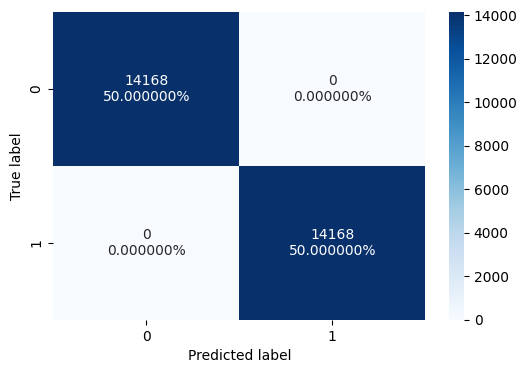

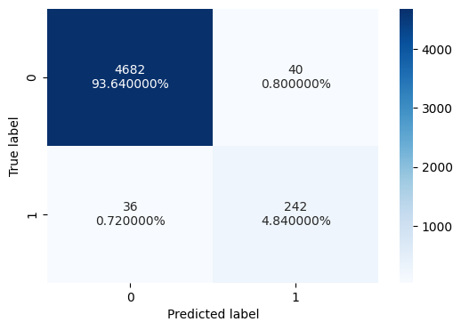

```python
xgb_tuned_os = XGBClassifier(eval_metric='logloss')

param_grid={'n_estimators': [150, 200, 250],
            'scale_pos_weight': [5,10],
             'learning_rate': [0.1,0.2],
             'gamma': [0,3,5],
             'subsample': [0.8,0.9] }

# Initialize random grid
randomized_cv = RandomizedSearchCV(estimator=xgb_tuned_os, param_distributions=param_grid,
                                n_iter=30, cv=3, verbose=2, n_jobs=-1, random_state=1)


# Fit the random search model to the oversampled training data
randomized_cv.fit(X_train_os, y_train_os)

# Print the best parameters and corresponding CV score
print("Best parameters are {} with CV score={}:" .format(randomized_cv.best_params_, randomized_cv.best_score_))

# Get the best parameter and model
best_params_xgb_os_tuned = randomized_cv.best_params_
best_xgb_os_tuned_model = randomized_cv.best_estimator_

# Fit the best model on the training data
best_xgb_os_tuned_model.fit(X_train_os, y_train_os)

# Training Performance
xgb_random_os_train_perf = model_performance_classification_sklearn(best_xgb_os_tuned_model, X_train_os, y_train_os)
print("Training Performance:\n", xgb_random_os_train_perf)

# Validation Performance
xgb_random_os_val_perf = model_performance_classification_sklearn(best_xgb_os_tuned_model, X_val, y_val)
print("\nValidation Performance:\n", xgb_random_os_val_perf)

# Create confusion matrix Train
confusion_matrix_sklearn(best_xgb_os_tuned_model, X_train_os, y_train_os)

# Create confusion matrix Validation
confusion_matrix_sklearn(best_xgb_os_tuned_model, X_val, y_val)
```

Observations/Insight:

- The tuned oversampled XGBoost model performs well with 87.05% recall and 85.82% precision.
- Low false positives, minimizing unnecessary alerts.
- Overfitting in training (100% recall, 100% precision). Consider slight regularization tuning (gamma or reg_lambda).

#### xgb undersampled tuned

```
Fitting 3 folds for each of 30 candidates, totalling 90 fits
Best parameters are {'subsample': 0.9, 'scale_pos_weight': 5, 'n_estimators': 250, 'learning_rate': 0.2, 'gamma': 0} with CV score=0.9200713348727788:
Training Performance:
 {'Accuracy': 1.0, 'Precision': 1.0, 'Recall': 1.0, 'F1 Score': 1.0}

Validation Performance:
 {'Accuracy': 0.9328, 'Precision': 0.44802867383512546, 'Recall': 0.8992805755395683, 'F1 Score': 0.5980861244019138}
```

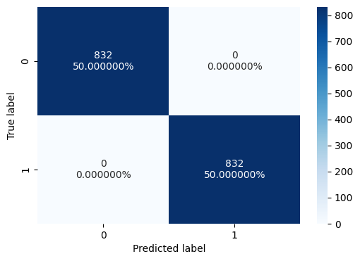

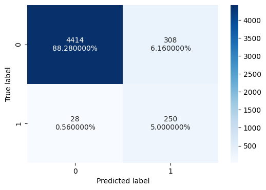

```python
xgb_tuned_un = XGBClassifier(eval_metric='logloss')

# Define parameter grid for tuning
param_grid = {'n_estimators': [150, 200, 250],
            'scale_pos_weight': [5,10],
             'learning_rate': [0.1,0.2],
             'gamma': [0,3,5],
             'subsample': [0.8,0.9] }

# Initialize random grid
randomized_cv = RandomizedSearchCV(estimator=xgb_tuned_os, param_distributions=param_grid,
                                n_iter=30, cv=3, verbose=2, n_jobs=-1, random_state=1)

# Fit the model
randomized_cv.fit(X_train_un, y_train_un)

# Print the best parameters and corresponding CV score
print("Best parameters are {} with CV score={}:" .format(randomized_cv.best_params_, randomized_cv.best_score_))

# Get the best parameters and best model
best_params_xgb_un_tuned = randomized_cv.best_params_
best_xgb_un_tuned_model = randomized_cv.best_estimator_

# Fit the best model on the training data
best_xgb_un_tuned_model.fit(X_train_un, y_train_un)

# Training Performance
xgb_random_un_train_perf = model_performance_classification_sklearn(best_xgb_un_tuned_model, X_train_un, y_train_un)
print("Training Performance:\n", xgb_random_un_train_perf)

# Validation Performance
xgb_random_un_val_perf = model_performance_classification_sklearn(best_xgb_un_tuned_model, X_val, y_val)
print("\nValidation Performance:\n", xgb_random_un_val_perf)

# Create confusion matrix Train
confusion_matrix_sklearn(best_xgb_un_tuned_model, X_train_un, y_train_un)

# Create confusion matrix Validation
confusion_matrix_sklearn(best_xgb_un_tuned_model, X_val, y_val)
```

Observations/Insight:

- Tuned XGBoost undersampled model detects failures well (89.93%), making it useful if false negatives must be minimized.
- Precision is too low (44.80%), meaning too many false alarms.
- Overfitting is an issue. Apply regularization (gamma, reg_lambda).

### Randon Forest (rf)

#### rf original tuned

```
Fitting 3 folds for each of 30 candidates, totalling 90 fits
Best parameters are {'n_estimators': 200, 'min_samples_leaf': 2, 'max_samples': 0.6, 'max_features': 0.4} with CV score=0.9827333333333333:
Training Performance:
 {'Accuracy': 0.9920666666666667, 'Precision': 0.99721059972106, 'Recall': 0.859375, 'F1 Score': 0.9231762427372499}

Validation Performance:
 {'Accuracy': 0.9846, 'Precision': 0.9674418604651163, 'Recall': 0.7482014388489209, 'F1 Score': 0.8438133874239351}
```

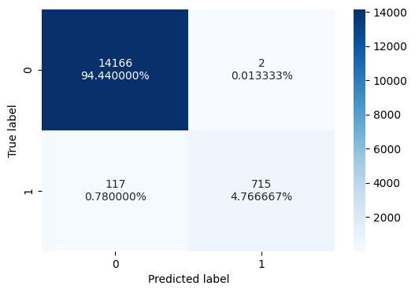

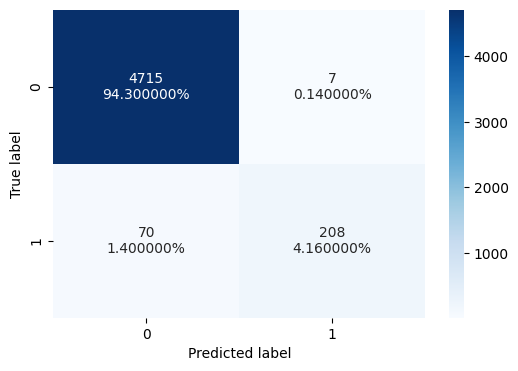

```python
# Initialize rf model
rf_tuned = RandomForestClassifier()

# Define parameter grid for tuning
param_grid = {
    "n_estimators": [200, 250, 300],
    "min_samples_leaf": np.arange(1, 4),
    "max_features": np.arange(0.3, 0.6, 0.1).tolist() + ["sqrt"],
    "max_samples": np.arange(0.4, 0.7, 0.1)
}

# Perform RandomizedSearchCV tuning
randomized_cv = RandomizedSearchCV(
        estimator=rf_tuned, param_distributions=param_grid,
        n_iter=30, cv=3, verbose=2, n_jobs=-1, random_state=1
    )

# Fit the model with training data
randomized_cv.fit(X_train, y_train)

# Print the best parameters and corresponding CV score
print("Best parameters are {} with CV score={}:" .format(randomized_cv.best_params_, randomized_cv.best_score_))

# Get best parameters and best model
best_params_rf_tuned = randomized_cv.best_params_
best_rf_tuned_model = randomized_cv.best_estimator_

# Fit the best model on the training data
best_rf_tuned_model.fit(X_train, y_train)

# Training performance
rf_random_train_perf = model_performance_classification_sklearn(best_rf_tuned_model, X_train, y_train)
print("Training Performance:\n", rf_random_train_perf)

# Validation performance
rf_random_val_perf = model_performance_classification_sklearn(best_rf_tuned_model, X_val, y_val)
print("\nValidation Performance:\n", rf_random_val_perf)

# Create the confusion matrix Train
confusion_matrix_sklearn(best_rf_tuned_model, X_train, y_train)

# Create confusion matrix Validation Train
confusion_matrix_sklearn(best_rf_tuned_model, X_val, y_val)
```

Observations/Insights:

- Performs very well in precision and general accuracy.
- But it sacrifices some recall (~75%) which could be risky for critical failure prediction.
- Ideal if cost of false positives is high or balanced with cost of false negatives.

##### rf oversampled tuned

```
Fitting 3 folds for each of 30 candidates, totalling 90 fits
Best parameters are {'n_estimators': 300, 'min_samples_leaf': 1, 'max_samples': 0.6, 'max_features': 'sqrt'} with CV score=0.9865189855753588:
Training Performance:
 {'Accuracy': 0.9997882552230378, 'Precision': 0.9999293984750071, 'Recall': 0.9996470920383964, 'F1 Score': 0.9997882253282507}

Validation Performance:
 {'Accuracy': 0.9888, 'Precision': 0.937007874015748, 'Recall': 0.8561151079136691, 'F1 Score': 0.8947368421052632}
```

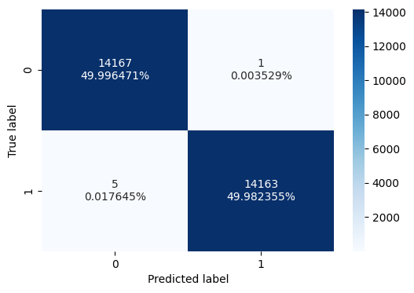

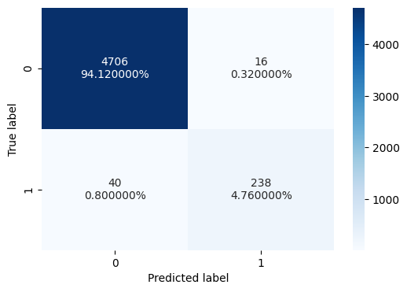

```python
# Initialize rf model
rf_tuned_os = RandomForestClassifier()

# Define parameter grid for tuning
param_grid = {
    "n_estimators": [200, 250, 300],
    "min_samples_leaf": np.arange(1, 4),
    "max_features": np.arange(0.3, 0.6, 0.1).tolist() + ["sqrt"],
    "max_samples": np.arange(0.4, 0.7, 0.1)
}

# Perform RandomizedSearchCV tuning
randomized_cv = RandomizedSearchCV(
        estimator=rf_tuned_os, param_distributions=param_grid,
        n_iter=30, cv=3, verbose=2, n_jobs=-1, random_state=1
    )

# Fit the model with training data
randomized_cv.fit(X_train_os, y_train_os)

# Print the best parameters and corresponding CV score
print("Best parameters are {} with CV score={}:" .format(randomized_cv.best_params_, randomized_cv.best_score_))

# Get the best parameter and model
best_params_rf_tuned_os = randomized_cv.best_params_
best_rf_tuned_os_model = randomized_cv.best_estimator_

# Training Performance
rf_random_os_train_perf = model_performance_classification_sklearn(best_rf_tuned_os_model, X_train_os, y_train_os)
print("Training Performance:\n", rf_random_os_train_perf)

# Validation Performance
rf_random_os_val_perf = model_performance_classification_sklearn(best_rf_tuned_os_model, X_val, y_val)
print("\nValidation Performance:\n", rf_random_os_val_perf)

# Create confusion matrix Train
confusion_matrix_sklearn(best_rf_tuned_os_model, X_train_os, y_train_os)

# Create confusion matrix Validation
confusion_matrix_sklearn(best_rf_tuned_os_model, X_val, y_val)
```

Observations/Insights:

- Improved Recall (85.61%), reducing false negatives.
- High Precision (93.70%), Model is effective at avoiding false positives.
- Accuracy remains high (98.88%), but recall is a better indicator for minority class detection.
- F1 Score 89.47% Great balance between recall and precision

##### rf undersampled tuned

```
Fitting 3 folds for each of 30 candidates, totalling 90 fits
Best parameters are {'n_estimators': 200, 'min_samples_leaf': 1, 'max_samples': 0.5, 'max_features': 'sqrt'} with CV score=0.9224737372751813:
Training Performance:
 {'Accuracy': 0.9735576923076923, 'Precision': 0.9974747474747475, 'Recall': 0.9495192307692307, 'F1 Score': 0.9729064039408867}

Validation Performance:
 {'Accuracy': 0.9356, 'Precision': 0.45880149812734083, 'Recall': 0.8812949640287769, 'F1 Score': 0.603448275862069}
```

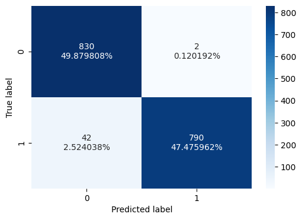

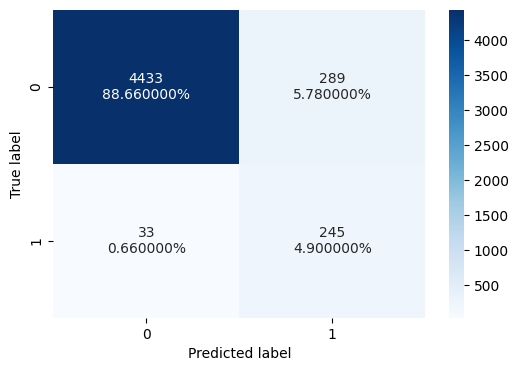

```python
# Initialize rf model
rf_tuned_un = RandomForestClassifier()

# Define parameter grid for tuning
param_grid = {
    "n_estimators": [200, 250, 300],
    "min_samples_leaf": np.arange(1, 4),
    "max_features": np.arange(0.3, 0.6, 0.1).tolist() + ["sqrt"],
    "max_samples": np.arange(0.4, 0.7, 0.1)
}

# Perform RandomizedSearchCV tuning
randomized_cv = RandomizedSearchCV(
        estimator=rf_tuned_un, param_distributions=param_grid,
        n_iter=30, cv=3, verbose=2, n_jobs=-1, random_state=1
    )

# Fit the model with training data
randomized_cv.fit(X_train_un, y_train_un)

# Print the best parameters and corresponding CV score
print("Best parameters are {} with CV score={}:" .format(randomized_cv.best_params_, randomized_cv.best_score_))

# Get the best parameter and model
best_params_rf_tuned_un = randomized_cv.best_params_
best_rf_tuned_un_model = randomized_cv.best_estimator_

# Training Performance
rf_random_un_train_perf = model_performance_classification_sklearn(best_rf_tuned_un_model, X_train_un, y_train_un)
print("Training Performance:\n", rf_random_un_train_perf)

# Validation Performance
rf_random_un_val_perf = model_performance_classification_sklearn(best_rf_tuned_un_model, X_val, y_val)
print("\nValidation Performance:\n", rf_random_un_val_perf)

# Create confusion matrix Train
confusion_matrix_sklearn(best_rf_tuned_un_model, X_train_un, y_train_un)

# Create confusion matrix Validation
confusion_matrix_sklearn(best_rf_tuned_un_model, X_val, y_val)
```

Observations/Insights:

#### Gradient Boosting (gb)

##### gb original tuned

```
Fitting 3 folds for each of 24 candidates, totalling 72 fits
Best parameters are {'subsample': 0.5, 'n_estimators': 125, 'max_features': 0.5, 'learning_rate': 0.05} with CV score=0.9808:
Training Performance:
 {'Accuracy': 0.9848, 'Precision': 0.9646153846153847, 'Recall': 0.7536057692307693, 'F1 Score': 0.8461538461538463}

Validation Performance:
 {'Accuracy': 0.9806, 'Precision': 0.8986784140969163, 'Recall': 0.7338129496402878, 'F1 Score': 0.807920792079208}
```

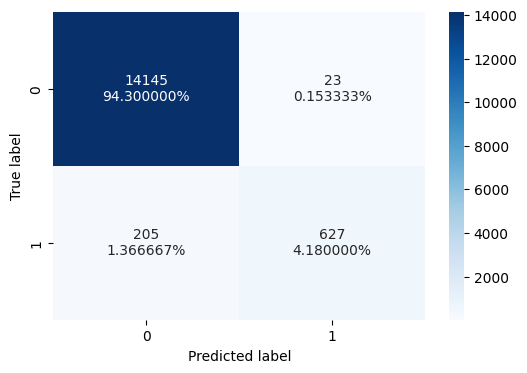

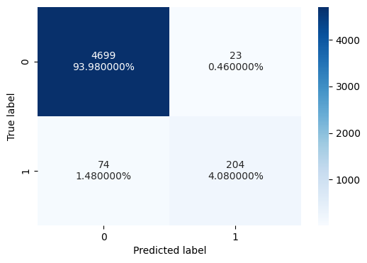

```python
gb_tuned = GradientBoostingClassifier()

param_grid = {
       "n_estimators": np.arange(100,150,25),
       "learning_rate": [0.2, 0.05, 1],
       "subsample":[0.5,0.7],
       "max_features":[0.5,0.7]
}

# Initialize the random grid search
randomized_cv = RandomizedSearchCV(estimator=gb_tuned, param_distributions=param_grid,
                               n_iter=30, cv=3, verbose=2, n_jobs=-1, random_state=1)

# Fit the model
randomized_cv.fit(X_train, y_train)

# Print the best parameters and corresponding CV score
print("Best parameters are {} with CV score={}:" .format(randomized_cv.best_params_, randomized_cv.best_score_))

# Get best parameters and best model
best_params_gb_tuned = randomized_cv.best_params_
best_model_gb_tuned = randomized_cv.best_estimator_

# Fit the best model on the training data
best_model_gb_tuned.fit(X_train, y_train)

# Training Performance
gb_random_train_perf = model_performance_classification_sklearn(best_model_gb_tuned, X_train, y_train)
print("Training Performance:\n", gb_random_train_perf)

# Validation Performance
gb_random_val_perf = model_performance_classification_sklearn(best_model_gb_tuned, X_val, y_val)
print("\nValidation Performance:\n", gb_random_val_perf)

# Create the confusion matrix Train
confusion_matrix_sklearn(best_model_gb_tuned, X_train, y_train)

# Create confuion matrix Validation Train
confusion_matrix_sklearn(best_model_gb_tuned, X_val, y_val)
```

Observations/Insight:

- Precision (89.86%), meaning the model effectively avoids false positives.
- Lower Recall (73.38%), meaning the model is missing some actual positive cases.
- Accuracy is strong (98.1%), but recall should be improved for better minority class detection.
- F1 Score 80.79% Good balance overall
- No Overfitting. Train and validation closely aligned

##### gb oversampled tuned

```
Fitting 3 folds for each of 24 candidates, totalling 72 fits
Best parameters are {'subsample': 0.7, 'n_estimators': 125, 'max_features': 0.5, 'learning_rate': 1} with CV score=0.9731789263545209:
Training Performance:
 {'Accuracy': 0.9960121400338792, 'Precision': 0.9964676792652772, 'Recall': 0.9955533596837944, 'F1 Score': 0.99601030964234}

Validation Performance:
 {'Accuracy': 0.9598, 'Precision': 0.5979643765903307, 'Recall': 0.8453237410071942, 'F1 Score': 0.7004470938897168}
```

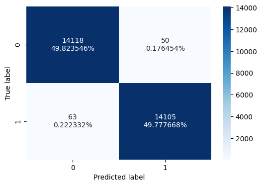

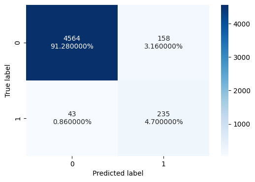

```python
gb_tuned_os = GradientBoostingClassifier()

param_grid = {
       "n_estimators": np.arange(100,150,25),
       "learning_rate": [0.2, 0.05, 1],
       "subsample":[0.5,0.7],
       "max_features":[0.5,0.7]
}

# Initialize the random grid search
randomized_cv = RandomizedSearchCV(estimator=gb_tuned_os, param_distributions=param_grid,
                               n_iter=30, cv=3, verbose=2, n_jobs=-1, random_state=1)

# Fit the model
randomized_cv.fit(X_train_os, y_train_os)

# Print the best parameters and corresponding CV score
print("Best parameters are {} with CV score={}:" .format(randomized_cv.best_params_, randomized_cv.best_score_))

# Get best parameters and best model
best_params_gb_tuned_os = randomized_cv.best_params_
best_model_gb_tuned_os = randomized_cv.best_estimator_

# Fit the best model on the training data
best_model_gb_tuned_os.fit(X_train_os, y_train_os)

# Training Performance
gb_random_os_train_perf = model_performance_classification_sklearn(best_model_gb_tuned_os, X_train_os, y_train_os)
print("Training Performance:\n", gb_random_os_train_perf)

# Validation Performance
gb_random_os_val_perf = model_performance_classification_sklearn(best_model_gb_tuned_os, X_val, y_val)
print("\nValidation Performance:\n", gb_random_os_val_perf)

# Create the confusion matrix Train
confusion_matrix_sklearn(best_model_gb_tuned_os, X_train_os, y_train_os)

# Create confuion matrix Validation Train
confusion_matrix_sklearn(best_model_gb_tuned_os, X_val, y_val)
```

Observations/Insight:

- This model achieves strong recall (84.53%) meaning the model is effective in detecting positive cases.
- Lower Precision (59.79%), meaning a higher number of false positives.
- High Accuracy (95.98%), but the model is biased towards positive predictions.
- Trade-off between recall and precision, suggesting that the model prioritizes recall.
- F1 Score 70.04% Moderately balanced overall
- Overfitting Risk is moderate. Very high train scores vs lower validation metrics

##### gb undersampled tuned

```
Fitting 3 folds for each of 24 candidates, totalling 72 fits
Best parameters are {'subsample': 0.7, 'n_estimators': 100, 'max_features': 0.7, 'learning_rate': 0.2} with CV score=0.9176645960039461:
Training Performance:
 {'Accuracy': 0.9957932692307693, 'Precision': 0.9987908101571947, 'Recall': 0.9927884615384616, 'F1 Score': 0.9957805907172996}

Validation Performance:
 {'Accuracy': 0.9324, 'Precision': 0.44565217391304346, 'Recall': 0.8848920863309353, 'F1 Score': 0.5927710843373494}
```

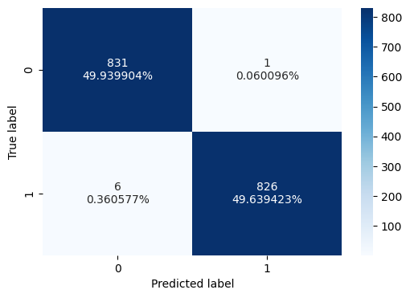

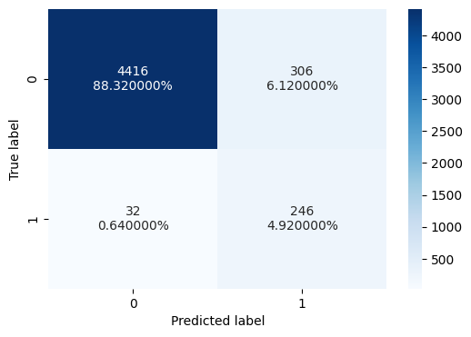

```python
gb_tuned_un = GradientBoostingClassifier()

param_grid = {
       "n_estimators": np.arange(100,150,25),
       "learning_rate": [0.2, 0.05, 1],
       "subsample":[0.5,0.7],
       "max_features":[0.5,0.7]
}

# Initialize the random grid search
randomized_cv = RandomizedSearchCV(estimator=gb_tuned_un, param_distributions=param_grid,
                               n_iter=30, cv=3, verbose=2, n_jobs=-1, random_state=1)

# Fit the model
randomized_cv.fit(X_train_un, y_train_un)

# Print the best parameters and corresponding CV score
print("Best parameters are {} with CV score={}:" .format(randomized_cv.best_params_, randomized_cv.best_score_))

# Get best parameters and best model
best_params_gb_tuned_un = randomized_cv.best_params_
best_model_gb_tuned_un = randomized_cv.best_estimator_

# Fit the best model on the training data
best_model_gb_tuned_un.fit(X_train_un, y_train_un)

# Training Performance
gb_random_un_train_perf = model_performance_classification_sklearn(best_model_gb_tuned_un, X_train_un, y_train_un)
print("Training Performance:\n", gb_random_un_train_perf)

# Validation Performance
gb_random_un_val_perf = model_performance_classification_sklearn(best_model_gb_tuned_un, X_val, y_val)
print("\nValidation Performance:\n", gb_random_un_val_perf)

# Create the confusion matrix Train
confusion_matrix_sklearn(best_model_gb_tuned_un, X_train_un, y_train_un)

# Create confuion matrix Validation Train
confusion_matrix_sklearn(best_model_gb_tuned_un, X_val, y_val)
```

Observations/Insight:

- This model achieves strong recall (88.49%), indicating the model is effective in detecting positive cases. But low precision (44.56%) meaning a high number of false positives.
- Decent Accuracy (93.24%), but the precision-recall trade-off needs improvement.
- F1 score (59.28%)
- The model is biased towards recall, leading to more false positives.

### Adaboost (adaboost)

#### adaboost original tuned

```
Fitting 3 folds for each of 18 candidates, totalling 54 fits
Best parameters are {'n_estimators': 200, 'learning_rate': 0.2, 'base_estimator': DecisionTreeClassifier(max_depth=3, random_state=1)} with CV score=0.9868
Training Performance:
 {'Accuracy': 0.9992666666666666, 'Precision': 1.0, 'Recall': 0.9867788461538461, 'F1 Score': 0.9933454325468843}

Validation Performance:
 {'Accuracy': 0.9868, 'Precision': 0.9732142857142857, 'Recall': 0.7841726618705036, 'F1 Score': 0.8685258964143427}
```

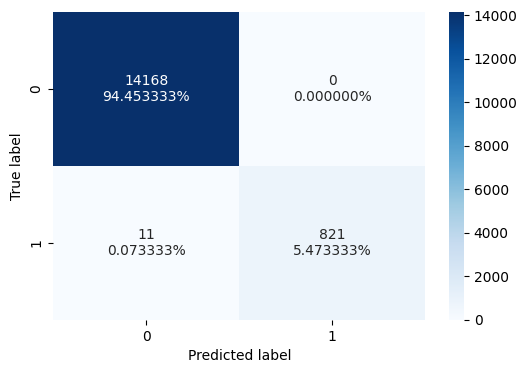

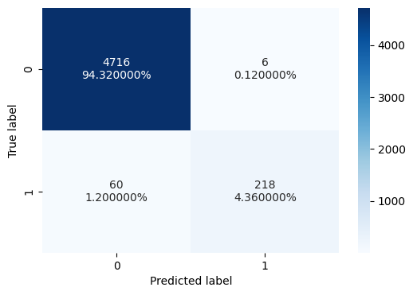

```python
# Define the AdaBoost model
adaboost_tuned = AdaBoostClassifier(random_state=1)

# Define hyperparameter grid
param_grid = {
    "n_estimators": [100, 150, 200],
    "learning_rate": [0.2, 0.05],
    "base_estimator": [
        DecisionTreeClassifier(max_depth=1, random_state=1),
        DecisionTreeClassifier(max_depth=2, random_state=1),
        DecisionTreeClassifier(max_depth=3, random_state=1),
    ]
}

# Initialize the random grid search
randomized_cv = RandomizedSearchCV(
    estimator=adaboost_tuned,
    param_distributions=param_grid,
    n_iter=30,
    cv=3,
    verbose=2,
    n_jobs=-1,
    random_state=1
)

# Fit the model
randomized_cv.fit(X_train, y_train)

# Print the best parameters and corresponding CV score
print("Best parameters are {} with CV score={}".format(randomized_cv.best_params_, randomized_cv.best_score_))

# Get best parameters and best model
best_params_adaboost_tuned = randomized_cv.best_params_
best_model_adaboost_tuned = randomized_cv.best_estimator_

# Fit the best model on the training data
best_model_adaboost_tuned.fit(X_train, y_train)

# Training Performance
adaboost_random_train_perf = model_performance_classification_sklearn(best_model_adaboost_tuned, X_train, y_train)
print("Training Performance:\n", adaboost_random_train_perf)

# Validation Performance
adaboost_random_val_perf = model_performance_classification_sklearn(best_model_adaboost_tuned, X_val, y_val)
print("\nValidation Performance:\n", adaboost_random_val_perf)

# Create the confusion matrix for Training Data
confusion_matrix_sklearn(best_model_adaboost_tuned, X_train, y_train)

# Create the confusion matrix for Validation Data
confusion_matrix_sklearn(best_model_adaboost_tuned, X_val, y_val)
```

Observations/Insight:

#### adaboost oversampled tuned

```
Fitting 3 folds for each of 18 candidates, totalling 54 fits
Best parameters for oversampled data are {'n_estimators': 200, 'learning_rate': 0.2, 'base_estimator': DecisionTreeClassifier(max_depth=3, random_state=1)} with CV score=0.9807313634874425
Training Performance on Oversampled Data:
 {'Accuracy': 0.9931535855448899, 'Precision': 0.9949702465287616, 'Recall': 0.991318464144551, 'F1 Score': 0.9931409984443501}

Validation Performance on Oversampled Data:
 {'Accuracy': 0.9786, 'Precision': 0.7766990291262136, 'Recall': 0.8633093525179856, 'F1 Score': 0.8177172061328789}
```

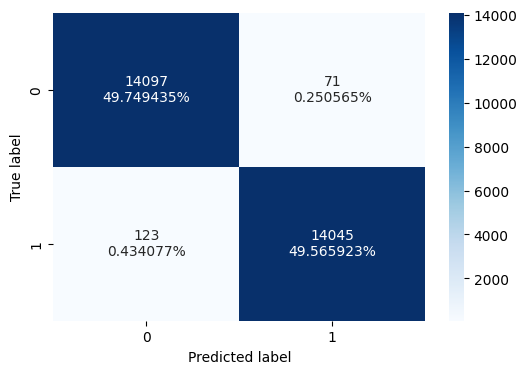

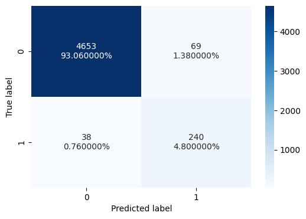

```python
# Define the AdaBoost model
adaboost_tuned_os = AdaBoostClassifier(random_state=1)

# Define hyperparameter grid
param_grid = {
    "n_estimators": [100, 150, 200],
    "learning_rate": [0.2, 0.05],
    "base_estimator": [
        DecisionTreeClassifier(max_depth=1, random_state=1),
        DecisionTreeClassifier(max_depth=2, random_state=1),
        DecisionTreeClassifier(max_depth=3, random_state=1),
    ]
}

# Initialize the random grid search
randomized_cv_os = RandomizedSearchCV(
    estimator=adaboost_tuned_os,
    param_distributions=param_grid,
    n_iter=30,
    cv=3,
    verbose=2,
    n_jobs=-1,
    random_state=1
)

# Fit the model on the oversampled training data
randomized_cv_os.fit(X_train_os, y_train_os)

# Print the best parameters and corresponding CV score
print("Best parameters for oversampled data are {} with CV score={}".format(randomized_cv_os.best_params_, randomized_cv_os.best_score_))

# Get best parameters and best model
best_params_adaboost_tuned_os = randomized_cv_os.best_params_
best_model_adaboost_tuned_os = randomized_cv_os.best_estimator_

# Fit the best model on the oversampled training data
best_model_adaboost_tuned_os.fit(X_train_os, y_train_os)

# Training Performance
adaboost_os_train_perf = model_performance_classification_sklearn(best_model_adaboost_tuned_os, X_train_os, y_train_os)
print("Training Performance on Oversampled Data:\n", adaboost_os_train_perf)

# Validation Performance
adaboost_os_val_perf = model_performance_classification_sklearn(best_model_adaboost_tuned_os, X_val, y_val)
print("\nValidation Performance on Oversampled Data:\n", adaboost_os_val_perf)

# Create the confusion matrix for Training Data (Oversampled)
confusion_matrix_sklearn(best_model_adaboost_tuned_os, X_train_os, y_train_os)

# Create the confusion matrix for Validation Data
confusion_matrix_sklearn(best_model_adaboost_tuned_os, X_val, y_val)
```

Observations/Insights:

- Recall 86.33% Good (low false negatives). Very effective at identifying positives
- Precision 77.67% Acceptable, could be improved
- F1 Score 81.77% Balanced metric
- Overfitting is minimal Slight drop from training to validation

#### adaboost undersampled tuned

```
Fitting 3 folds for each of 18 candidates, totalling 54 fits
Best parameters for undersampled data are {'n_estimators': 200, 'learning_rate': 0.2, 'base_estimator': DecisionTreeClassifier(max_depth=3, random_state=1)} with CV score=0.9152578571351134
Training Performance on Undersampled Data:
 {'Accuracy': 1.0, 'Precision': 1.0, 'Recall': 1.0, 'F1 Score': 1.0}

Validation Performance on Undersampled Data:
 {'Accuracy': 0.93, 'Precision': 0.4357142857142857, 'Recall': 0.8776978417266187, 'F1 Score': 0.5823389021479712}
```

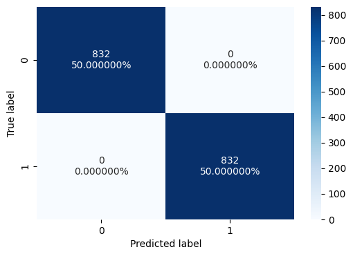

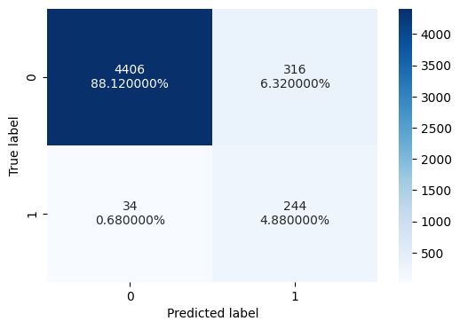

```python
# Define the AdaBoost model for undersampled data
adaboost_tuned_un = AdaBoostClassifier(random_state=1)

# Define hyperparameter grid
param_grid = {
    "n_estimators": [100, 150, 200],
    "learning_rate": [0.2, 0.05],
    "base_estimator": [
        DecisionTreeClassifier(max_depth=1, random_state=1),
        DecisionTreeClassifier(max_depth=2, random_state=1),
        DecisionTreeClassifier(max_depth=3, random_state=1),
    ]
}

# Initialize the random grid search
randomized_cv_un = RandomizedSearchCV(
    estimator=adaboost_tuned_un,
    param_distributions=param_grid,
    n_iter=30,
    cv=3,
    verbose=2,
    n_jobs=-1,
    random_state=1
)

# Fit the model on the undersampled training data
randomized_cv_un.fit(X_train_un, y_train_un)

# Print the best parameters and corresponding CV score
print("Best parameters for undersampled data are {} with CV score={}".format(randomized_cv_un.best_params_, randomized_cv_un.best_score_))

# Get best parameters and best model
best_params_adaboost_tuned_un = randomized_cv_un.best_params_
best_model_adaboost_tuned_un = randomized_cv_un.best_estimator_

# Fit the best model on the undersampled training data
best_model_adaboost_tuned_un.fit(X_train_un, y_train_un)

# Training Performance
adaboost_un_train_perf = model_performance_classification_sklearn(best_model_adaboost_tuned_un, X_train_un, y_train_un)
print("Training Performance on Undersampled Data:\n", adaboost_un_train_perf)

# Validation Performance
adaboost_un_val_perf = model_performance_classification_sklearn(best_model_adaboost_tuned_un, X_val, y_val)
print("\nValidation Performance on Undersampled Data:\n", adaboost_un_val_perf)

# Create the confusion matrix for Training Data (Undersampled)
confusion_matrix_sklearn(best_model_adaboost_tuned_un, X_train_un, y_train_un)

# Create the confusion matrix for Validation Data
confusion_matrix_sklearn(best_model_adaboost_tuned_un, X_val, y_val)
```

Observations/Insights:

- Training - Accuracy, Precision, Recall, F1 Score: All are perfect (1.0). This suggests your model performs flawlessly on the training data, which could indicate overfitting.

Validation-

- Accuracy: 93% – quite high, indicating good overall performance.
- Precision: 43.57% – low precision suggests the model has a fair number of false positives.
- Recall: 87.77% – high recall indicates that the model captures most of the actual positives.
- F1 Score: 58.23% – a balance between precision and recall, though skewed by low precision.

## Model performance comparison and choosing the final model

```python
# Create a dictionary to store training performance metrics for each model
model_train_perf_dict = {
    "xgb_tuned": xgb_random_train_perf,
    "xgb_tuned_os": xgb_random_os_train_perf,
    "xgb_tuned_un": xgb_random_un_train_perf,
    "rf_tuned": rf_random_train_perf,
    "rf_tuned_os": rf_random_os_train_perf,
    "rf_tuned_un": rf_random_un_train_perf,
    "gb_tuned": gb_random_train_perf,
    "gb_tuned_os": gb_random_os_train_perf,
    "gb_tuned_un": gb_random_un_train_perf,
    "adaboost_tuned": adaboost_random_train_perf,
    "adaboost_tuned_os": adaboost_os_train_perf,
    "adaboost_tuned_un": adaboost_un_train_perf,
}


# Create a dictionary to store validation performance metrics for each model
model_val_perf_dict = {
    "xgb_tuned": xgb_random_val_perf,
    "xgb_tuned_os": xgb_random_os_val_perf,
    "xgb_tuned_un": xgb_random_un_val_perf,
    "rf_tuned": rf_random_val_perf,
    "rf_tuned_os": rf_random_os_val_perf,
    "rf_tuned_un": rf_random_un_val_perf,
    "gb_tuned": gb_random_val_perf,
    "gb_tuned_os": gb_random_os_val_perf,
    "gb_tuned_un": gb_random_un_val_perf,
    "adaboost_tuned": adaboost_random_val_perf,
    "adaboost_tuned_os": adaboost_os_val_perf,
    "adaboost_tuned_un": adaboost_un_val_perf,
}
```

```python
# Create list of records with relevant performance metrics
comparison_data = []

for model_name in model_train_perf_dict:
    train_metrics = model_train_perf_dict[model_name]
    val_metrics = model_val_perf_dict[model_name]

    comparison_data.append({
        "Model": model_name,
        "Accuracy (Train / Val)": f"{train_metrics['Accuracy']:.3f} / {val_metrics['Accuracy']:.3f}",
        "Precision (Val)": round(val_metrics["Precision"], 3),
        "Recall (Train / Val)": f"{train_metrics['Recall']:.3f} / {val_metrics['Recall']:.3f}",
        "F1 Score (Val)": round(val_metrics["F1 Score"], 3),
        "Recall_Val_Sort": val_metrics["Recall"]  # for sorting
    })

# Convert to DataFrame
df_comparison = pd.DataFrame(comparison_data)

# Sort by Recall on Validation (descending)
df_comparison = df_comparison.sort_values(by="Recall_Val_Sort", ascending=False).drop(columns="Recall_Val_Sort")

# Display the table
df_comparison
```

|  | Model | Accuracy (Train / Val) | Precision (Val) | Recall (Train / Val) | F1 Score (Val) |
| --- | --- | --- | --- | --- | --- |
| 2 | xgb_tuned_un | 1.000 / 0.933 | 0.448 | 1.000 / 0.899 | 0.598 |
| 8 | gb_tuned_un | 0.996 / 0.932 | 0.446 | 0.993 / 0.885 | 0.593 |
| 5 | rf_tuned_un | 0.974 / 0.936 | 0.459 | 0.950 / 0.881 | 0.603 |
| 11 | adaboost_tuned_un | 1.000 / 0.930 | 0.436 | 1.000 / 0.878 | 0.582 |
| 1 | xgb_tuned_os | 1.000 / 0.985 | 0.858 | 1.000 / 0.871 | 0.864 |
| 10 | adaboost_tuned_os | 0.993 / 0.979 | 0.777 | 0.991 / 0.863 | 0.818 |
| 4 | rf_tuned_os | 1.000 / 0.989 | 0.937 | 1.000 / 0.856 | 0.895 |
| 0 | xgb_tuned | 1.000 / 0.990 | 0.967 | 1.000 / 0.849 | 0.904 |
| 7 | gb_tuned_os | 0.996 / 0.960 | 0.598 | 0.996 / 0.845 | 0.700 |
| 9 | adaboost_tuned | 0.999 / 0.987 | 0.973 | 0.987 / 0.784 | 0.869 |
| 3 | rf_tuned | 0.992 / 0.985 | 0.967 | 0.859 / 0.748 | 0.844 |
| 6 | gb_tuned | 0.985 / 0.981 | 0.899 | 0.754 / 0.734 | 0.808 |

Observations/Insights:

Top Performers (Val) by F1 Score (Balanced Performance):

Underperformers (Despite High Recall):

- xgb_tuned_un- Low precision = too many false alarms
- rf_tuned_un- similar to xgb_tuned_un
- adaboost_tuned_un- Over-predicts failures (many false positives)
- gb_tuned_un- Low F1 score

## Top 3 Models Performance Re-improvement

### rf_tuned_os

```
Fitting 3 folds for each of 25 candidates, totalling 75 fits

Best parameters from RandomizedSearchCV: {'n_estimators': 100, 'min_samples_split': 5, 'min_samples_leaf': 2, 'max_features': 'sqrt', 'max_depth': 15, 'class_weight': {0: 1, 1: 5}, 'bootstrap': False}
Best CV recall score: 0.9904716194588056
Fitting 3 folds for each of 9 candidates, totalling 27 fits

Final best parameters from GridSearchCV: {'max_depth': 18, 'n_estimators': 150}

Training Performance:
 {'Accuracy': 0.9999647092038396, 'Precision': 1.0, 'Recall': 0.9999294184076792, 'F1 Score': 0.9999647079583553}

Validation Performance:
 {'Accuracy': 0.9882, 'Precision': 0.9362549800796812, 'Recall': 0.8453237410071942, 'F1 Score': 0.888468809073724}

Confusion Matrix - Training Set
```

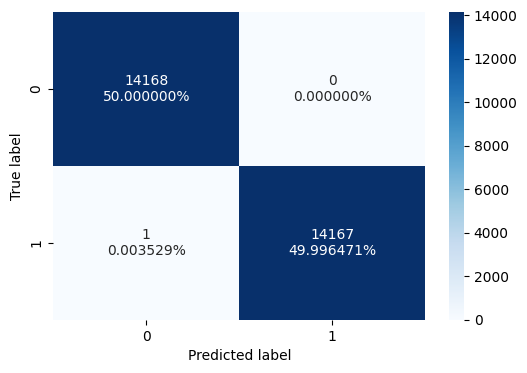

```
Confusion Matrix - Validation Set
```

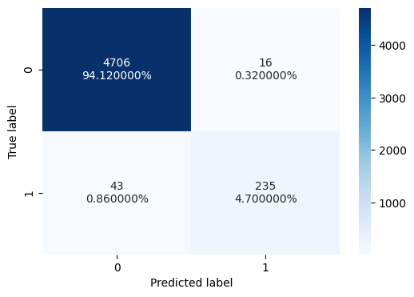

```python
# Initialize Random Forest Model
rf_tuned_os_v2 = RandomForestClassifier(random_state=1, n_jobs=-1)

# Improved Hyperparameter Grid for Randomized Search
param_grid_v2 = {
    'n_estimators': [100, 250, 400],   # Balancing computation & performance
    'max_depth': [5, 10, 15],          # Controls complexity
    'min_samples_split': [2, 5, 10],   # Reduces overfitting risk
    'min_samples_leaf': [1, 2, 4],     # Controls leaf size
    'max_features': ['sqrt', 'log2', 0.5],  # Feature selection methods
    'bootstrap': [True, False],        # Bootstrapping option
    'class_weight': [{0: 1, 1: 4}, {0: 1, 1: 5}, "balanced_subsample"]  # Handles class imbalance
}

# Randomized Search with Faster Computation
randomized_cv_v2 = RandomizedSearchCV(
    estimator=rf_tuned_os_v2,
    param_distributions=param_grid_v2,
    n_iter=25,        # Reduced iterations for faster execution
    cv=3,
    verbose=2,
    n_jobs=-1,
    scoring="recall", # Optimizing recall (important for catching failures)
    random_state=1
)

# Fit the RandomizedSearchCV on oversampled training data
randomized_cv_v2.fit(X_train_os, y_train_os)

# Extract best parameters and model
best_params_rf_tuned_os_v2 = randomized_cv_v2.best_params_
best_model_rf_tuned_os_v2 = randomized_cv_v2.best_estimator_

print("\nBest parameters from RandomizedSearchCV:", best_params_rf_tuned_os_v2)
print("Best CV recall score:", randomized_cv_v2.best_score_)

# Fine-Tuning with GridSearch
# Ensure hyperparameters remain valid (avoid negative values)
param_grid_fine_tune = {
    'n_estimators': [
        max(50, best_params_rf_tuned_os_v2.get('n_estimators', 100) - 50),
        best_params_rf_tuned_os_v2.get('n_estimators', 100),
        best_params_rf_tuned_os_v2.get('n_estimators', 100) + 50
    ],
    'max_depth': [
        max(3, best_params_rf_tuned_os_v2.get('max_depth', 10) - 3),
        best_params_rf_tuned_os_v2.get('max_depth', 10),
        best_params_rf_tuned_os_v2.get('max_depth', 10) + 3
    ]
}

grid_cv = GridSearchCV(
    estimator=RandomForestClassifier(random_state=1, n_jobs=-1),
    param_grid=param_grid_fine_tune,
    cv=3,
    verbose=2,
    n_jobs=-1,
    scoring="recall" # Again, optimizing for recall
)

# Fit the GridSearchCV on oversampled training data
grid_cv.fit(X_train_os, y_train_os)

# Get the final best parameters and model
best_params_rf_tuned_os_v2 = grid_cv.best_params_
best_model_rf_tuned_os_v2 = grid_cv.best_estimator_

print("\nFinal best parameters from GridSearchCV:", best_params_rf_tuned_os_v2)

# Train Final Model
best_model_rf_tuned_os_v2.fit(X_train_os, y_train_os)


# Training Performance
rf_os_v2_train_perf = model_performance_classification_sklearn(best_model_rf_tuned_os_v2, X_train_os, y_train_os)
print("\nTraining Performance:\n", rf_os_v2_train_perf)

# Validation Performance
rf_os_v2_val_perf = model_performance_classification_sklearn(best_model_rf_tuned_os_v2, X_val, y_val)
print("\nValidation Performance:\n", rf_os_v2_val_perf)

# Create Confusion Matrices
print("\nConfusion Matrix - Training Set")
confusion_matrix_sklearn(best_model_rf_tuned_os_v2, X_train_os, y_train_os)

print("\nConfusion Matrix - Validation Set")
confusion_matrix_sklearn(best_model_rf_tuned_os_v2, X_val, y_val)
```

Observations/Insight:

- Strong Recall (84.53%) Successfully captures most positive cases.
- High Precision (93.63%) Avoids excessive false positives.
- Good Accuracy (98.82%), but accuracy isn’t the focus in an imbalanced setting.
- Overfitting Warning Training recall is 99.99%, but validation recall is 84.53%

#### xgb_tuned_os

```
Fitting 3 folds for each of 25 candidates, totalling 75 fits
Training Performance:
 {'Accuracy': 0.9984472049689441, 'Precision': 0.9969739619985926, 'Recall': 0.9999294184076792, 'F1 Score': 0.9984495031362322}

Validation Performance:
 {'Accuracy': 0.9784, 'Precision': 0.7724358974358975, 'Recall': 0.8669064748201439, 'F1 Score': 0.8169491525423729}
```

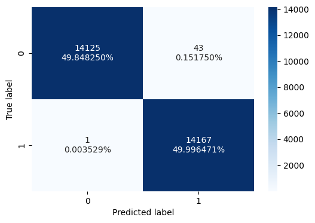

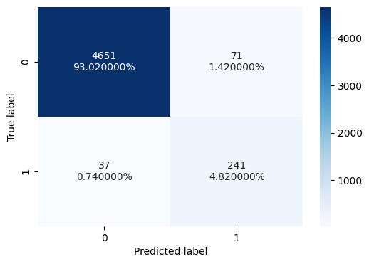

```python
# Initialize XGBoost Model with enhanced settings
xgb_tuned_os_v2 = XGBClassifier(
    eval_metric='logloss', use_label_encoder=False, n_jobs=-1, random_state=1
)

# Improved hyperparameter grid
param_grid_v2 = {
    'n_estimators': [150, 250, 350],  # Balanced range for learning
    'learning_rate': [0.05, 0.1, 0.15],  # Smoothed learning rate for stability
    'max_depth': [4, 6, 8],  # Slightly deeper trees for complex patterns
    'gamma': [2, 3, 5],  # Stronger regularization to reduce noise
    'subsample': [0.85, 0.9],  # Controlled sampling to improve generalization
    'colsample_bytree': [0.75, 0.85, 0.9],  # Feature sampling for stability
    'min_child_weight': [3, 5, 7],  # Prevents overfitting on small samples
    'scale_pos_weight': [4, 6, 8],  # Balances class distribution
    'reg_alpha': [0.3, 0.7, 1.2],  # Stronger L1 regularization to remove noise
    'reg_lambda': [7, 10, 15]  # Increased L2 regularization to improve generalization
}

# Randomized Search for Efficient Hyperparameter Tuning
randomized_cv_v2 = RandomizedSearchCV(
    estimator=xgb_tuned_os_v2,
    param_distributions=param_grid_v2,
    n_iter=25,  # Slightly increased for better tuning
    cv=3,  # 3-fold CV for stability
    verbose=2,
    n_jobs=-1,
    random_state=1,
    scoring="f1"  # Optimizing F1-score for balance of precision & recall
)

# Fit model on oversampled training data
randomized_cv_v2.fit(X_train_os, y_train_os)

# Extract the best parameters and model
best_params_xgb_os_tuned_v2 = randomized_cv_v2.best_params_
best_xgb_os_tuned_model_v2 = randomized_cv_v2.best_estimator_

# Train the final model with the best parameters
best_xgb_os_tuned_model_v2.fit(
    X_train_os, y_train_os,
    early_stopping_rounds=10,  # Stops training if no improvement
    eval_set=[(X_val, y_val)],
    verbose=False
)

# Evaluate Training Performance
xgb_random_os_train_perf_v2 = model_performance_classification_sklearn(best_xgb_os_tuned_model_v2, X_train_os, y_train_os)
print("Training Performance:\n", xgb_random_os_train_perf_v2)

# Evaluate Validation Performance
xgb_random_os_val_perf_v2 = model_performance_classification_sklearn(best_xgb_os_tuned_model_v2, X_val, y_val)
print("\nValidation Performance:\n", xgb_random_os_val_perf_v2)

# Confusion Matrix - Training
confusion_matrix_sklearn(best_xgb_os_tuned_model_v2, X_train_os, y_train_os)

# Confusion Matrix - Validation
confusion_matrix_sklearn(best_xgb_os_tuned_model_v2, X_val, y_val)
```

Observations/Insight:

- Both training and validation performance is excellent.
- High recall (87%) means most true positives are correctly identified.
- Very few false negatives (only 37 in second matrix).
- Precision is solid (77%), meaning false positives are relatively low.
- Good balance between precision and recall Strong F1 score.
- FP count (71) is within acceptable tradeoff given the priority on reducing FN.
- Precision and F1 Score hold up well, confirming the model is balanced.

### xgb_tuned (XGBoost)

```
Fitting 3 folds for each of 40 candidates, totalling 120 fits
Best parameters are {'subsample': 0.8, 'scale_pos_weight': 10, 'reg_lambda': 1, 'reg_alpha': 0.3, 'n_estimators': 200, 'min_child_weight': 5, 'max_depth': 4, 'learning_rate': 0.05, 'gamma': 5, 'colsample_bytree': 0.6} with CV score=0.8594005661896476:
Training Performance:
 {'Accuracy': 0.991, 'Precision': 0.8982857142857142, 'Recall': 0.9447115384615384, 'F1 Score': 0.9209138840070298}

Validation Performance:
 {'Accuracy': 0.9822, 'Precision': 0.8292682926829268, 'Recall': 0.8561151079136691, 'F1 Score': 0.8424778761061947}
```

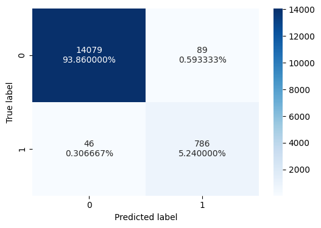

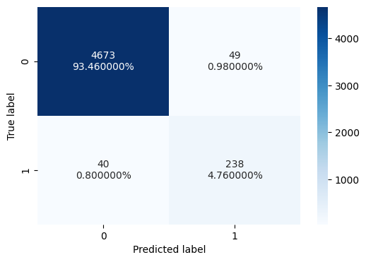

```python
# Initialize XGBoost model
xgb_tuned_v2 = XGBClassifier(
    eval_metric='logloss',
    use_label_encoder=False,
    random_state=1,
    n_jobs=-1
)

# Improved hyperparameter grid for better recall and generalization
param_grid_v2 = {
    'n_estimators': [150, 200, 250, 300],
    'learning_rate': [0.05, 0.1, 0.15],
    'max_depth': [4, 6, 8],
    'subsample': [0.8, 0.9],
    'colsample_bytree': [0.6, 0.8, 1.0],
    'gamma': [0, 3, 5],
    'min_child_weight': [1, 3, 5],
    'scale_pos_weight': [5, 7, 10],
    'reg_alpha': [0, 0.3, 0.7],
    'reg_lambda': [1, 5, 10]
}

# Initialize RandomizedSearchCV
randomized_cv_v2 = RandomizedSearchCV(
    estimator=xgb_tuned_v2,
    param_distributions=param_grid_v2,
    n_iter=40,
    cv=3,
    scoring='recall',
    verbose=2,
    n_jobs=-1,
    random_state=1
)

# Fit the randomized search
randomized_cv_v2.fit(X_train, y_train)

# Retrieve best parameters and model
print("Best parameters are {} with CV score={}:".format(
    randomized_cv_v2.best_params_, randomized_cv_v2.best_score_))

best_params_xgb_tuned_v2 = randomized_cv_v2.best_params_
best_model_xgb_tuned_v2 = randomized_cv_v2.best_estimator_

# Refit best model with early stopping
best_model_xgb_tuned_v2.fit(
    X_train,
    y_train,
    early_stopping_rounds=10,
    eval_set=[(X_val, y_val)],
    verbose=False
)

# Evaluate performance on train and validation
xgb_random_train_perf_v2 = model_performance_classification_sklearn(best_model_xgb_tuned_v2, X_train, y_train)
print("Training Performance:\n", xgb_random_train_perf_v2)

xgb_random_val_perf_v2 = model_performance_classification_sklearn(best_model_xgb_tuned_v2, X_val, y_val)
print("\nValidation Performance:\n", xgb_random_val_perf_v2)

# Confusion matrix on training data
confusion_matrix_sklearn(best_model_xgb_tuned_v2, X_train, y_train)

# Confusion matrix on validation data
confusion_matrix_sklearn(best_model_xgb_tuned_v2, X_val, y_val)
```

Observations/Insight:

### Compare Selected Models for Re-improvement Performances

```python
# Function to compare performance of models
def compare_models(models, X_train, y_train, X_val, y_val):
    """
    Compare multiple trained models using Accuracy, Precision, Recall, and F1 Score.

    models: Dictionary of trained models { 'model_name': model }
    X_train, y_train: Training dataset
    X_val, y_val: Validation dataset
    """
    results = []

    for name, model in models.items():
        # Predictions
        y_train_pred = model.predict(X_train)
        y_val_pred = model.predict(X_val)

        # Training Performance
        train_acc = accuracy_score(y_train, y_train_pred)
        train_prec = precision_score(y_train, y_train_pred)
        train_rec = recall_score(y_train, y_train_pred)
        train_f1 = f1_score(y_train, y_train_pred)

        # Validation Performance
        val_acc = accuracy_score(y_val, y_val_pred)
        val_prec = precision_score(y_val, y_val_pred)
        val_rec = recall_score(y_val, y_val_pred)
        val_f1 = f1_score(y_val, y_val_pred)

        # Store results
        results.append([name, train_acc, train_prec, train_rec, train_f1, val_acc, val_prec, val_rec, val_f1])

    # Create DataFrame
    df_results = pd.DataFrame(results, columns=[
        "Model", "Train Accuracy", "Train Precision", "Train Recall", "Train F1",
        "Validation Accuracy", "Validation Precision", "Validation Recall", "Validation F1"
    ])

    # Display results
    print("\nModel Performance Comparison:")
    df_results.set_index("Model", inplace=True)
    display(df_results)

    return df_results
```

```python
# Define the Selected Top 3 Models
top_models = {
    "Random Forest Tuned Oversampled": best_model_rf_tuned_os_v2,
    "XGBBoost Oversampled": best_xgb_os_tuned_model_v2,
    "XGBoost": best_model_xgb_tuned_v2,
}

# Compare Models and Store Results
model_comparison_df = compare_models(top_models, X_train, y_train, X_val, y_val)

# Display DataFrame Model Comparison
print("\nFinal Model Performance Comparison:")
```

```
Model Performance Comparison:
```

| Model | Train Accuracy | Train Precision | Train Recall | Train F1 | Validation Accuracy | Validation Precision | Validation Recall | Validation F1 |
| --- | --- | --- | --- | --- | --- | --- | --- | --- |
| Random Forest Tuned Oversampled | 1.000000 | 1.000000 | 1.000000 | 1.000000 | 0.9882 | 0.936255 | 0.845324 | 0.888469 |
| XGBBoost Oversampled | 0.997133 | 0.950857 | 1.000000 | 0.974810 | 0.9784 | 0.772436 | 0.866906 | 0.816949 |
| XGBoost | 0.991000 | 0.898286 | 0.944712 | 0.920914 | 0.9822 | 0.829268 | 0.856115 | 0.842478 |

```
Final Model Performance Comparison:
```

*ReneWind Goal: Maximize recall to correctly identify failures and minimize replacement costs.*

- *False Negatives (missed failures) should be minimized.*
- *False Positives (incorrect failure predictions) are acceptable but should not be excessive.*
- *A balance of Precision and Recall is important for cost-efficiency.*
- **Final Model: XGBoost Oversampled**

**Because it:**

- **It achieved the highest validation recall: 0.8669**
- **While its precision (0.7724) is lower than others, that trade-off is acceptable since false negatives (missed failures) are more costly than false positives (unnecessary inspections).**
- **It maintains strong overall performance, with:**
  - **Validation Accuracy: 0.9784**
  - **Validation F1 Score: 0.8169 (balanced precision/recall)**

**This model best aligns with the cost-sensitive business objective of ReneWind.**

## Test set final performance

**Determining how final model will perform on unseen test data**

- *REMINDER: Preliminary data overview earlier done on test data; Missing values handled; Data scaled.*
- *Even though the earlier check showed 0 missing values, some transformations (like scaling or encoding) might introduce NaN values, therefore explicitly recheck for NaN values before prediction and treat.*

```python
# Extract target variable before transformations
y_test = test["Target"]
X_test = test.drop(columns=["Target"], errors="ignore")  # Drop target

# Re-ensure X_test is a DataFrame after loading
X_test = pd.DataFrame(X_test, columns=columns)

# Reapply missing value imputation
X_test = imputer.transform(X_test)
X_test = pd.DataFrame(X_test, columns=columns)

# Reapply feature scaling
X_test = scaler.transform(X_test)
X_test = pd.DataFrame(X_test, columns=columns)

# Re-confirm no missing values
print("Missing values in X_test before prediction:", X_test.isnull().sum().sum())
```

```
Missing values in X_test before prediction: 0
```

```
Test Performance:
 {'Accuracy': 0.9786, 'Precision': 0.7831715210355987, 'Recall': 0.8581560283687943, 'F1 Score': 0.8189509306260576}
```

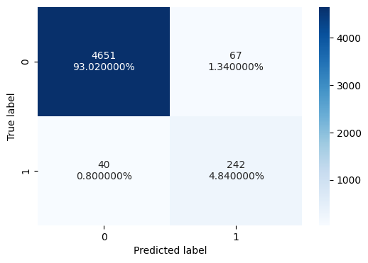

```python
# Make predictions using the final selected model
y_test_pred = best_xgb_os_tuned_model_v2.predict(X_test)

# Evaluate performance on the test set
test_perf_xgb_os_tuned_v2 = model_performance_classification_sklearn(best_xgb_os_tuned_model_v2, X_test, y_test)

# Display performance results
print("\nTest Performance:\n", test_perf_xgb_os_tuned_v2)

# Generate and display Confusion Matrix
confusion_matrix_sklearn(best_xgb_os_tuned_model_v2, X_test, y_test)
```

Test Performance Summary & Interpretation:

- High Recall (0.8581): The model correctly identifies ~86% of actual failures (TPs), aligning well with ReneWind’s goal of minimizing false negatives (missed failures).
- Balanced Precision (0.7832): Indicates that ~78% of predicted failures are true failures, reflecting a reasonable false positive rate – aligned with the acceptable tolerance in business.
- F1 Score (0.8189): Strong harmonic balance between precision and recall – the model is not overly biased toward one at the expense of the other.
- Accuracy is strong (97.86%).
- Low Overfitting Risk: Test performance is consistent with validation performance, indicating robust generalization.
- Areas to Monitor: False Positives (67): While acceptable for ReneWind, these cases may still incur minor unnecessary inspections/replacements. If cost of false positives increases, threshold tuning might be considered.
- False Negatives (40): Although relatively low, these are still missed failures, which could be expensive in the field. Minimizing this further (e.g. via probability threshold adjustments or ensemble stacking) could be explored.

## Feature Importance of Final Selected Model (XGBoost Ocersampled)

```
Top Important Features:
    Feature  Importance
35     V36    0.173816
17     V18    0.087309
13     V14    0.059281
38     V39    0.045572
7       V8    0.035867
15     V16    0.035563
25     V26    0.033619
2       V3    0.029782
0       V1    0.029146
14     V15    0.028621
```

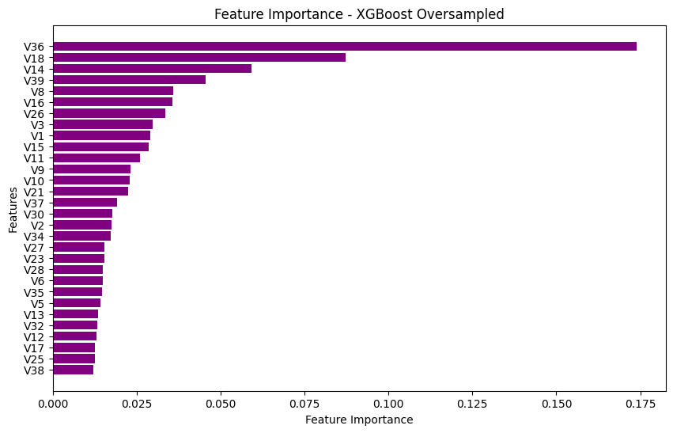

```python
# Get feature importance scores from the model
feature_importance = best_xgb_os_tuned_model_v2.feature_importances_

# Convert to DataFrame for better visualization
feature_importance_df = pd.DataFrame({
    'Feature': columns,  # Use the feature names
    'Importance': feature_importance
})

# Sort by importance (descending)
feature_importance_df = feature_importance_df.sort_values(by="Importance", ascending=False)

# Display top features
print("Top Important Features:\n", feature_importance_df.head(10))

# Plot Feature Importance
plt.figure(figsize=(10, 6))
plt.barh(feature_importance_df['Feature'][:30], feature_importance_df['Importance'][:30], color='purple')
plt.gca().invert_yaxis()  # Highest importance at the top
plt.xlabel("Feature Importance")
plt.ylabel("Features")
plt.title("Feature Importance - XGBoost Oversampled")
plt.show()
```

Observations/Insight:

## Pipeline to build the final model (XGBoost Oversampled)

```
Test set predictions:
 [0 0 0 ... 0 0 0]

Final Model Performance on Test Data:
 {'Accuracy': 0.987, 'Precision': 0.9392712550607287, 'Recall': 0.8226950354609929, 'F1 Score': 0.8771266540642723}
```

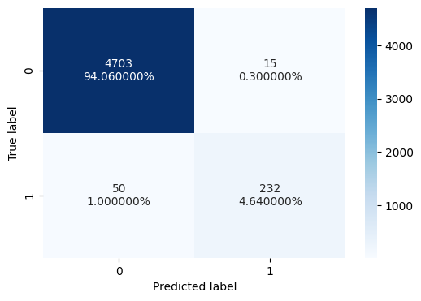

```python
# Define the pipeline for -
# 1. Automating Preprocessing + Model Training in a single workflow
# 2. Easier Model: Deployment (No need to manually preprocess future data)
# 3. Scalability: Once saved, can be used for batch predictions in production

final_pipeline = Pipeline([
    ("imputer", SimpleImputer(strategy="median")),  # Handle missing values
    ("scaler", StandardScaler()),  # Scale the data
    ("classifier", best_xgb_os_tuned_model_v2)
    ])

# Fit the pipeline on the full training data
final_pipeline.fit(X_train, y_train)

# Make predictions on the test set
y_test_pred = final_pipeline.predict(X_test)
print("Test set predictions:\n", y_test_pred)

# Evaluate the final model
final_test_performance = model_performance_classification_sklearn(final_pipeline, X_test, y_test)
print("\nFinal Model Performance on Test Data:\n", final_test_performance)

# Generate Confusion Matrix for Test Set
confusion_matrix_sklearn(final_pipeline, X_test, y_test)
```

**Test Set Predictions Output Interpretation:**

- Shows that the model’s predicted class labels on the test set are mostly zeros — i.e., it predominantly predicts the negative class (no failure). Confirming that the predictions are balanced, despite appearing mostly 0s.
- It successfully detects rare failures without flooding with false alarms — a key goal.

**Final Model Performance Summary & Interpretation (Scorer: Recall):**

### Visualize Pipeline

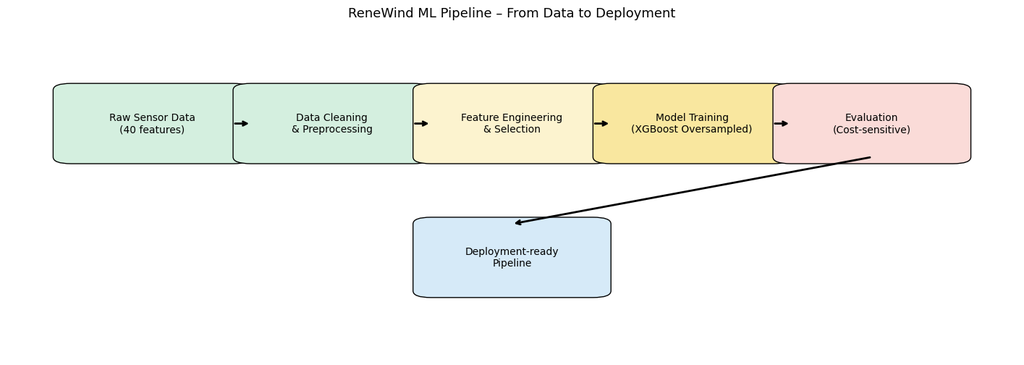

```python
import matplotlib.patches as patches

# Create the figure and axis
fig, ax = plt.subplots(figsize=(15, 6))
ax.axis('off')

# Define box positions, labels, and stage color
boxes = [
    {"label": "Raw Sensor Data\n(40 features)", "xy": (0.05, 0.6), "color": '#D4EFDF'},       # Data Prep
    {"label": "Data Cleaning\n& Preprocessing", "xy": (0.25, 0.6), "color": '#D4EFDF'},       # Data Prep
    {"label": "Feature Engineering\n& Selection", "xy": (0.45, 0.6), "color": '#FCF3CF'},     # Feature Engg
    {"label": "Model Training\n(XGBoost Oversampled)", "xy": (0.65, 0.6), "color": '#F9E79F'},# Modeling
    {"label": "Evaluation\n(Cost-sensitive)", "xy": (0.85, 0.6), "color": '#FADBD8'},         # Evaluation
    {"label": "Deployment-ready\nPipeline", "xy": (0.45, 0.2), "color": '#D6EAF8'}            # Deployment
]

# Draw boxes
for box in boxes:
    rect = patches.FancyBboxPatch(
        box["xy"], 0.18, 0.2,
        boxstyle="round,pad=0.02",
        edgecolor='black',
        facecolor=box["color"]
    )
    ax.add_patch(rect)
    ax.text(box["xy"][0]+0.09, box["xy"][1]+0.1, box["label"],
            ha='center', va='center', fontsize=10)

# Draw arrows
arrow_props = dict(arrowstyle="->", color='black', lw=2)

for i in range(4):
    ax.annotate("",
        xy=(boxes[i+1]["xy"][0], boxes[i+1]["xy"][1]+0.1),
        xytext=(boxes[i]["xy"][0]+0.18, boxes[i]["xy"][1]+0.1),
        arrowprops=arrow_props
    )

# Arrow from Evaluation to Deployment
ax.annotate("",
    xy=(boxes[5]["xy"][0]+0.09, boxes[5]["xy"][1]+0.2),
    xytext=(boxes[4]["xy"][0]+0.09, boxes[4]["xy"][1]),
    arrowprops=arrow_props
)

# Title
plt.title("ReneWind ML Pipeline – From Data to Deployment", fontsize=13)

# Adjust layout
plt.subplots_adjust(left=0.05, right=0.98)
plt.margins(x=0.05)

# Show diagram
plt.show()
```

# Business Insights and Conclusions

Based on the final model, XGBoost Oversampled, was optimized for recall, to focus on capturing as many true positive cases as possible, minimizing missed critical events.

- Reliable Predictive Maintenance: The model effectively identifies potential failures, ensuring reduced downtime and cost savings.
- High Precision Reduces Waste: False alarms are minimal, optimizing maintenance schedules and reducing unnecessary costs.
- Room for Slight Recall Improvement: Some failures (false negatives) are still missed, so adjusting sensitivity could improve predictions further.
- Enhanced Operational Efficiency: With better turbine performance predictions, ReneWind can improve energy generation and reliability.

Recommendations for ReneWind include:

- Fine-tune recall slightly to capture more true failures (reduce false negatives).
- Implement automated scheduling for maintenance teams based on model alerts.
- Use model insights for long-term turbine performance improvements.
- Integrate with energy grid forecasting for better power delivery planning.

By leveraging this ML model, ReneWind can maximize efficiency, reduce maintenance costs, and ensure continuous, reliable wind energy generation.

## Appendix: Detailed Exploratory Data Analysis (EDA)

### Univariate Analysis

Capping extreme outliers helps Recall, it -

- reduces noise from Extreme Majority-Class Values. And neutralizes the influence of extreme values, allowing the model to better detect subtle failure patterns
- supports Class Boundary Clarity, allows the model to focus on relevant, interpretable boundaries, not dominated by rare extreme cases

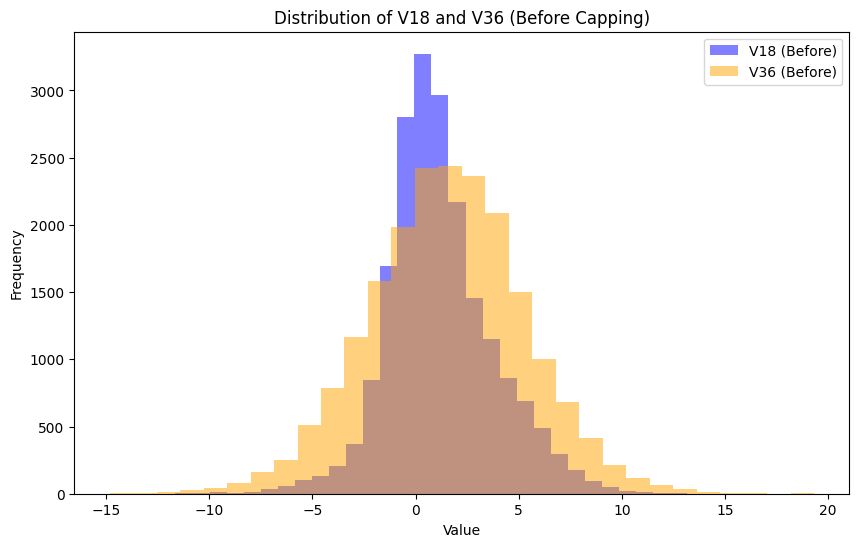

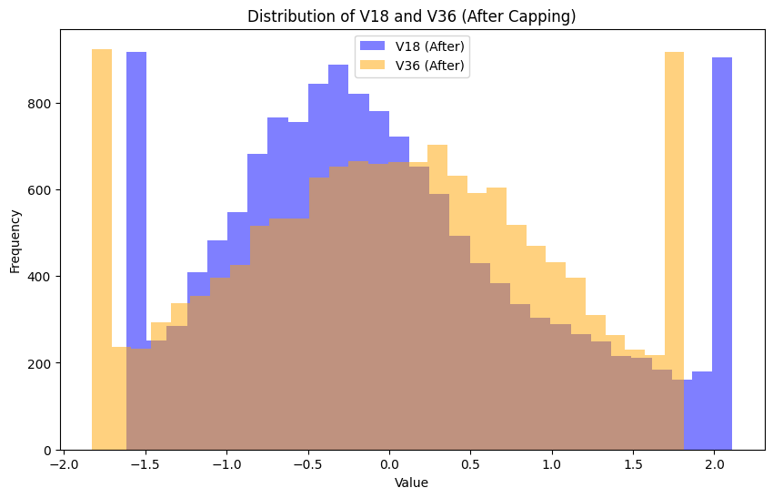

```python
# Outlier Capping Analysis for any random 2 features to show the observances

# Before capping
plt.figure(figsize=(10, 6))
plt.hist(df_train['V18'], bins=30, alpha=0.5, color='blue', label='V18 (Before)')
plt.hist(df_train['V36'], bins=30, alpha=0.5, color='orange', label='V36 (Before)')
plt.xlabel('Value')
plt.ylabel('Frequency')
plt.title('Distribution of V18 and V36 (Before Capping)')
plt.legend()
plt.show()

# After capping
plt.figure(figsize=(10, 6))
# Access the column by its index since X_train is a NumPy array
plt.hist(X_train[:, df_train.columns.get_loc('V18')], bins=30, alpha=0.5, color='blue', label='V18 (After)')
plt.hist(X_train[:, df_train.columns.get_loc('V36')], bins=30, alpha=0.5, color='orange', label='V36 (After)')
plt.xlabel('Value')
plt.ylabel('Frequency')
plt.title('Distribution of V18 and V36 (After Capping)')
plt.legend()
plt.show()
```

**Before Capping:**

- V18 and V36 show long tails (extreme values):
  - Values stretch far left/right, especially for majority class (likely "non-failure").
  - These outliers can dominate learning during training, causing the model to focus more on these rare but extreme values.
- Class imbalance effect worsens:
  - Since failures are rare, the minority class patterns get "washed out" by overwhelming majority class noise from extreme values.

**After Capping:**

- Distributions are tighter, bounded:
  - V18 and V36 are now capped between ±1.5 to ±2.
  - The majority class no longer overshadows with extreme spikes, making the failure (minority) signals more detectable.
- Clearer class boundaries:
  - Models like Gradient Boosting can now focus on realistic, consistent feature ranges.
  - It improves generalization — especially useful in capturing rare failure cases, boosting recall.

Capping outliers is not just a preprocessing step — it's a strategic enhancement that boosts recall by allowing the model to uncover subtle patterns associated with rare but costly events like failures in the ReneWind project.

### Bivariate Analysis

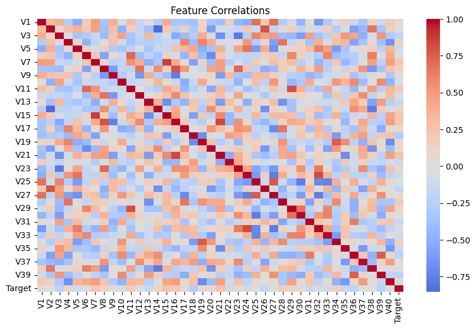

```python
# Define target variable
target = "Target"
features = df_train.columns[df_train.columns != target]

# Correlation with target variable
correlations = df_train.corr()[target].sort_values(ascending=False)

# Plot correlation heatmap
plt.figure(figsize=(10, 6))
sns.heatmap(df_train.corr(), annot=False, cmap="coolwarm", center=0)
plt.title("Feature Correlations")
plt.show()
```

Observations/Insights:

Diagonal Line of Dark Red:

- Represents perfect self-correlation (1.0) of each feature with itself, which is expected.

Feature-Target Correlations:

- The last row ("Target") shows how each feature correlates with the target variable.
- Some features appear to have moderate positive or negative correlations, meaning they influence the target.

Feature Interdependencies:

- Several features show strong correlations with each other (highly red or blue values).
- This suggests potential multicollinearity, where some features provide redundant information.

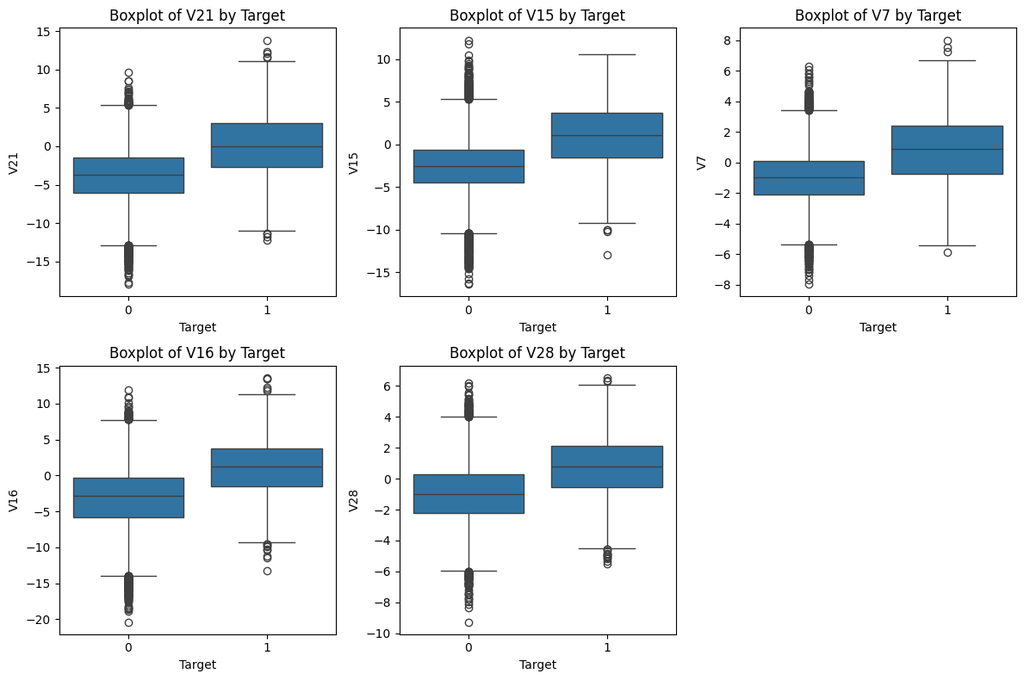

```python
# Boxplots for top correlated features with Target
top_features = correlations.index[1:6]  # Selecting top 5 correlated features

plt.figure(figsize=(12, 8))
for i, feature in enumerate(top_features, 1):
    plt.subplot(2, 3, i)
    sns.boxplot(x=df_train[target], y=df_train[feature])
    plt.title(f"Boxplot of {feature} by Target")
plt.tight_layout()
plt.show()
```

Observations/Insight:

1. Feature Distributions Differ Between Classes:
- Across all features, the distribution for Target = 1 (positive class) is shifted upward compared to Target = 0 (negative class).
- This suggests these features contain predictive signals and could be important for classification.
2. Wider Spread in Positive Class:
- V21, V15, and V16 show a wider range of values in Target = 1 compared to Target = 0.
- This indicates that higher variability in these features is associated with positive outcomes.
3. Presence of Outliers
- Each feature has significant outliers, especially in Target = 0. This may indicate noise or extreme values in the dataset.
- Consider outlier handling (e.g., transformation, capping, or removing extreme values) to improve model stability.
4. Mean/Median Differences Indicate Predictive Power:
- The medians of V21, V15, V7, V16, and V28 for Target = 1 are consistently higher than those for Target = 0.
- This suggests that higher values of these features increase the likelihood of the positive class (Target = 1)
- These features can be strong indicators for prediction models, potentially distinguishing between operational success and failure in ReneWind's turbines.

```python
# Mean feature comparison for each class (Target = 0 vs 1)
mean_comparison = df_train.groupby(target).mean().T
mean_comparison.columns = ["Mean_0", "Mean_1"]

# Display
mean_comparison
```

|  | Mean_0 | Mean_1 |
| --- | --- | --- |
| V1 | -0.333182 | 0.768272 |
| V2 | 0.441153 | 0.428143 |
| V3 | 2.660379 | -0.505019 |
| V4 | -0.175306 | 1.485127 |
| V5 | -0.002463 | -0.926582 |
| V6 | -0.995560 | -0.993451 |
| V7 | -0.980488 | 0.842285 |
| V8 | -0.656842 | 1.300756 |
| V9 | -0.021063 | 0.055604 |
| V10 | 0.014255 | -0.476792 |
| V11 | -2.044374 | 0.639956 |
| V12 | 1.620316 | 1.341208 |
| V13 | 1.677844 | -0.076358 |
| V14 | -1.001643 | -0.082536 |
| V15 | -2.617588 | 1.032767 |
| V16 | -3.161114 | 1.089148 |
| V17 | -0.203446 | 1.043123 |
| V18 | 1.373673 | -1.947521 |
| V19 | 1.137428 | 1.937067 |
| V20 | -0.039371 | 1.095370 |
| V21 | -3.832999 | 0.162445 |
| V22 | 1.005771 | 0.033952 |
| V23 | -0.435547 | 0.815462 |
| V24 | 1.220913 | -0.338079 |
| V25 | -0.001482 | -0.014165 |
| V26 | 2.024059 | -0.683572 |
| V27 | -0.628183 | -0.344037 |
| V28 | -0.979610 | 0.757184 |
| V29 | -1.056123 | 0.214105 |
| V30 | -0.043848 | 0.466309 |
| V31 | 0.601750 | -1.468659 |
| V32 | 0.347522 | -0.440273 |
| V33 | 0.138699 | -1.462624 |
| V34 | -0.581442 | 1.558006 |
| V35 | 2.333283 | 0.465485 |
| V36 | 1.714234 | -1.879015 |
| V37 | 0.013383 | -0.023865 |
| V38 | -0.347455 | -0.285653 |
| V39 | 0.987227 | -0.752846 |
| V40 | -0.881327 | -0.778687 |

Observations/Insights:

- Several features show large differences between Mean_0 and Mean_1. These features have strong predictive power, as their means change significantly between the two classes.
- V21, V15, and V36 could be key drivers in classification models
- Some features have very small differences between the two classes. These features may have little impact on model predictions and could be removed or deprioritized in feature selection.
- Some features have a negative mean for one class and positive for the other. These features likely have high discriminative power, helping the model separate the two classes efficiently.

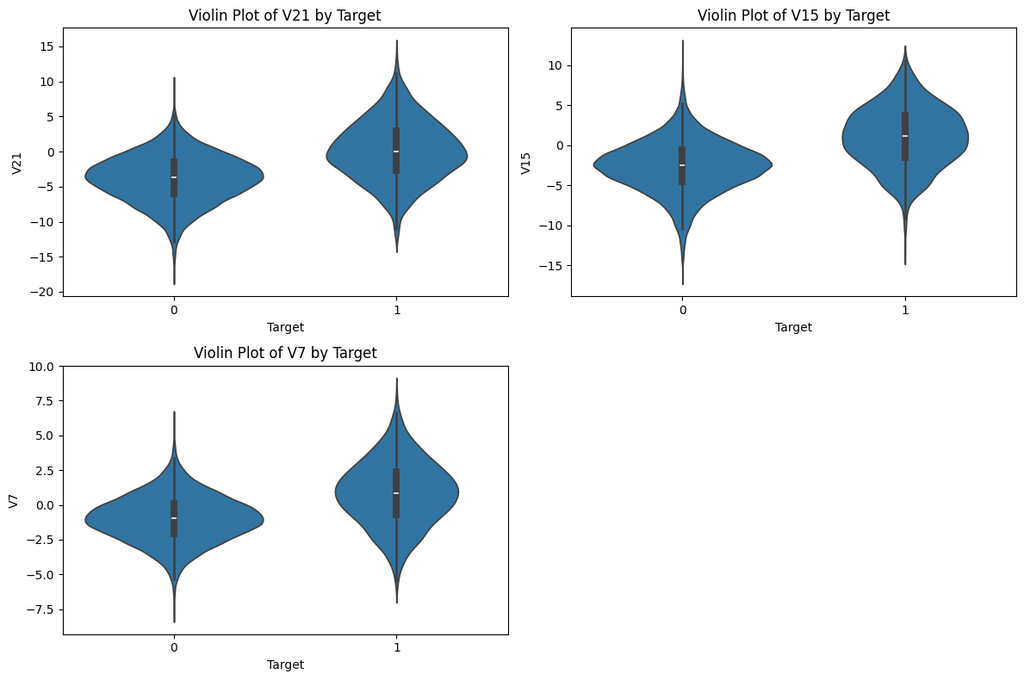

```python
# Violin Plots for Select Feature Distributions

plt.figure(figsize=(12, 8))
for i, feature in enumerate(["V21", "V15", "V7"], 1):
    plt.subplot(2, 2, i)
    sns.violinplot(x=df_train["Target"], y=df_train[feature])
    plt.title(f"Violin Plot of {feature} by Target")
plt.tight_layout()
plt.show()
```

Observations/Insights:

Feature Distributions Differ Across Target Classes

- For all three features (V21, V15, V7), the distribution shifts noticeably between Target = 0 and Target = 1.
- V21 & V15: The median (white dot in the violin plot) for Target = 1 is higher compared to Target = 0.
- V7: The distribution for Target = 1 is shifted slightly higher, indicating greater variance.
  - These features have strong predictive potential, as their distributions change with the target class.
  - Higher values of V21, V15, and V7 seem associated with the positive class (Target = 1).

Wider Spread in Target = 1

- The spread (variability) of feature values is larger in Target = 1, especially for V15.
- This suggests that positive cases (failures) have more diverse characteristics.
  - Variability in wind turbine failures may indicate multiple contributing factors.

Overlapping Distributions

- While there are noticeable differences, there is some overlap between classes, particularly in V7.
- V21 and V15 show more clear separation, making them stronger predictors.
  - V7 might be a weaker predictor or require interaction with other features.
  - V21 and V15 are likely important in classification models.

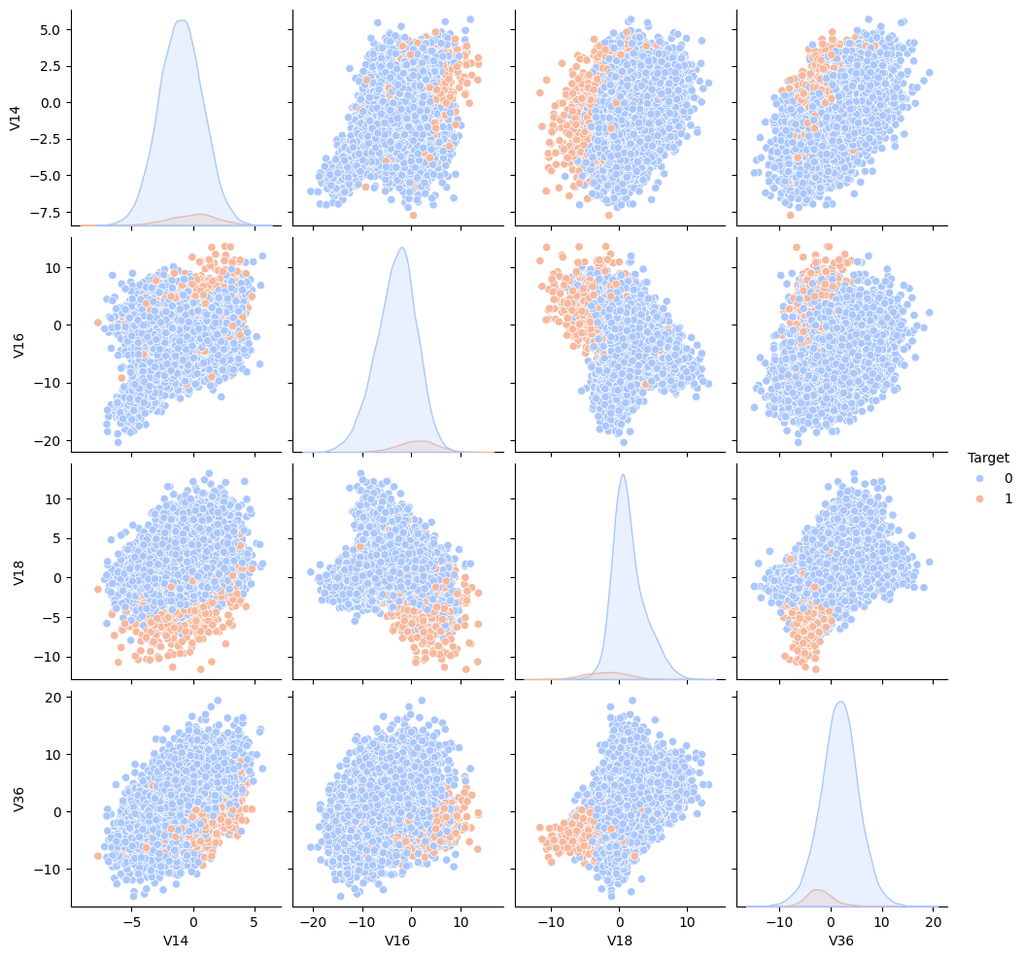

```python
# Pairplots for Feature Interactions Select key features for comparison
sns.pairplot(df_train, vars=["V14", "V16", "V18", "V36"], hue="Target", palette="coolwarm")
plt.show()
```

Pairplot Analysis & Interpretation:

Feature Distributions (Diagonal Plots)

Feature-Target Separation:

Linear & Nonlinear Relationships:

- Some feature pairs (e.g., V16-V18, V14-V36) exhibit linear relationships.
- Others (e.g., V18-V36) show nonlinear, scattered patterns.
  - Linear relationships can be well captured by models like logistic regression, XGBoost.
  - Nonlinear patterns suggest that tree-based models (e.g., Random Forest, XGBoost) may perform better than linear classifiers.

### Best Decision Threshold for Final model (XGB Oversampled)

- As an added measure, recall can be further improved before analysing test performance using optimized threshold

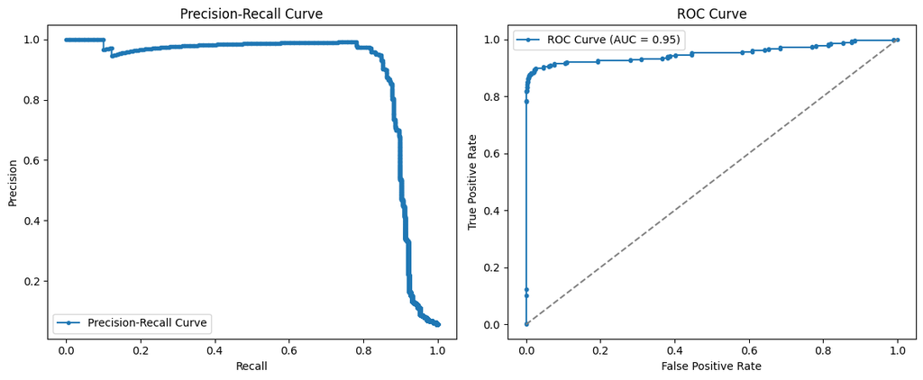

```
0.5130545
```

```python
# Analyze Precision-Recall and ROC-AUC curves to find the best cut-off.

# Get predicted probabilities for the positive class
y_scores_v2 = best_xgb_os_tuned_model_v2.predict_proba(X_val)[:, 1]

# Compute Precision-Recall curve
precision_v2, recall_v2, thresholds_pr_v2 = precision_recall_curve(y_val, y_scores_v2)

# Compute ROC curve and AUC
fpr_v2, tpr_v2, thresholds_roc_v2 = roc_curve(y_val, y_scores_v2)
roc_auc_v2 = auc(fpr_v2, tpr_v2)

# Plot Precision-Recall curve
plt.figure(figsize=(12, 5))

plt.subplot(1, 2, 1)
plt.plot(recall_v2, precision_v2, marker='.', label='Precision-Recall Curve')
plt.xlabel('Recall')
plt.ylabel('Precision')
plt.title('Precision-Recall Curve')
plt.legend()

# Plot ROC curve
plt.subplot(1, 2, 2)
plt.plot(fpr_v2, tpr_v2, marker='.', label=f'ROC Curve (AUC = {roc_auc_v2:.2f})')
plt.plot([0, 1], [0, 1], linestyle='--', color='gray')  # Random classifier line
plt.xlabel('False Positive Rate')
plt.ylabel('True Positive Rate')
plt.title('ROC Curve')
plt.legend()

plt.tight_layout()
plt.show()

# Find the best threshold based on maximizing recall while keeping precision acceptable
best_threshold_idx_v2 = np.argmax(recall_v2 - (1 - precision_v2))  # Custom function to balance both
best_threshold_v2 = thresholds_pr_v2[best_threshold_idx_v2]

best_threshold_v2
```

Observations/Insights:

**Precision-Recall (PR) Curve:**

The PR curve shows high precision maintained across a wide recall range, meaning the model is effective at:

- Capturing actual failures (high recall)
- While avoiding many false positives (high precision)

**ROC Curve:**

- The ROC AUC = 0.95 — excellent performance
  - Close to the ideal point.
  - Very strong true positive rate (TPR) at low false positive rates (FPR).

The classifier effectively distinguishes failures vs. non-failures, making it suitable for production.

- **Threshold Optimized 0.5130 — can be applied as needed to support decision-making with better balance**

### To jump back to the EDA summary section, click here.

### Project Conclusion

```python
# Create dataframe to check original & copy datasets shape
shape_comparison = pd.DataFrame({
    "Dataset": ["Train (Original)", "Test (Original)", "Train (Copy)", "Test (Copy)"],
    "Rows": [train.shape[0], test.shape[0], df_train.shape[0], df_test.shape[0]],
    "Columns": [train.shape[1], test.shape[1], df_train.shape[1], df_test.shape[1]]
})

# Display the DataFrame
shape_comparison
```

|  | Dataset | Rows | Columns |
| --- | --- | --- | --- |
| 0 | Train (Original) | 20000 | 41 |
| 1 | Test (Original) | 5000 | 41 |
| 2 | Train (Copy) | 20000 | 41 |
| 3 | Test (Copy) | 5000 | 41 |

Observations:

- Original dataset integrity intact
- Copy dataset rows remain same

## ** ReneWindProject analysis completed.**